# Summarizing Data

Summary Statistics, Frequency Tables, and Journal-Style Table 1

# 1 Introduction

In addition to visualization, **summarizing data** helps you gain insights about a dataset. In this section, we’ll review the most common summary statistics and how to compute them in R. We’ll start with overall summaries and discuss why certain summaries (e.g., mean vs. median) are preferable under skewed distributions, and how to handle missing values. We then build toward presenting summary statistics in a publishable table — a **“Table 1”** like the one at the start of most scientific journal articles.

Things to keep in mind

- Always check **missingness** before making a table or plot; decide whether to impute, drop, or flag.
- Use **medians/IQRs** for skewed data; **means/SDs** for roughly symmetric distributions.
- `summarize()` must return **one value per group/column**; functions like `range()` return two values, so use `min()` and `max()`, or switch to `reframe()`.
- For frequency tables, use `prop.table(tab, 1)` for **row** proportions and `prop.table(tab, 2)` for **column** proportions.
- **Label and scale** variables for readability (e.g., millions/billions).
- Set `options(digits = 2)` to display tidy tables without altering underlying precision.

Packages you’ll need `tidyverse`, `dslabs` (for `gapminder`), and `tableone` for the journal-style tables. Install any you’re missing with `install.packages(“…”)`, and keep `crimson.css` in the same folder when you knit.

# 2 Numerical Summaries

We’ll use the `gapminder` dataset once again, starting with the base R `summary` function. It gives min/median/mean/quartiles for numeric variables and counts for factors/characters — a good first look before deeper work.

```r
library(dslabs)
library(tidyverse)
data(gapminder)
summary(gapminder)   # Min/median/mean/quartiles per numeric column; counts for factors
```

```
#>                 country           year      infant_mortality life_expectancy
#>  Albania            :   57   Min.   :1960   Min.   :  1.50   Min.   :13.20
#>  Algeria            :   57   1st Qu.:1974   1st Qu.: 16.00   1st Qu.:57.50
#>  Angola             :   57   Median :1988   Median : 41.50   Median :67.54
#>  Antigua and Barbuda:   57   Mean   :1988   Mean   : 55.31   Mean   :64.81
#>  Argentina          :   57   3rd Qu.:2002   3rd Qu.: 85.10   3rd Qu.:73.00
#>  Armenia            :   57   Max.   :2016   Max.   :276.90   Max.   :83.90
#>  (Other)            :10203                  NA's   :1453
#>    fertility       population             gdp               continent
#>  Min.   :0.840   Min.   :3.124e+04   Min.   :4.040e+07   Africa  :2907
#>  1st Qu.:2.200   1st Qu.:1.333e+06   1st Qu.:1.846e+09   Americas:2052
#>  Median :3.750   Median :5.009e+06   Median :7.794e+09   Asia    :2679
#>  Mean   :4.084   Mean   :2.701e+07   Mean   :1.480e+11   Europe  :2223
#>  3rd Qu.:6.000   3rd Qu.:1.523e+07   3rd Qu.:5.540e+10   Oceania : 684
#>  Max.   :9.220   Max.   :1.376e+09   Max.   :1.174e+13
#>  NA's   :187     NA's   :185         NA's   :2972
#>              region
#>  Western Asia   :1026
#>  Eastern Africa : 912
#>  Western Africa : 912
#>  Caribbean      : 741
#>  South America  : 684
#>  Southern Europe: 684
#>  (Other)        :5586
```

We can also use `summary` with the pipe — for example, after `filter`.

```r
gapminder %>%
  filter(year == 1986) %>%
  select(life_expectancy) %>%
  summary()
```

```
#>  life_expectancy
#>  Min.   :41.39
#>  1st Qu.:58.96
#>  Median :68.48
#>  Mean   :65.57
#>  3rd Qu.:71.85
#>  Max.   :78.38
```

Let’s store just the 1986 life expectancy values (after removing `NA`s) so we can compute specific statistics one by one. Remember:

- **Mean** is sensitive to outliers.
- **Median** is robust to skew/outliers.
- **Standard deviation (sd) / variance** quantify spread around the mean.
- **Range** (min, max) and **IQR** (Q3 − Q1) capture overall and middle-50% spread, respectively.

```r
gapminder_1986 <- gapminder %>%
  filter(year == 1986 & !is.na(life_expectancy))   # Drop NAs so the stats compute cleanly

le_1986 <- gapminder_1986$life_expectancy          # Pull the column out as a vector

mean(le_1986)     # Average
```

```
#> [1] 65.57362
```

```r
median(le_1986)   # Middle value (robust to outliers)
```

```
#> [1] 68.48
```

```r
sd(le_1986)       # Standard deviation
```

```
#> [1] 8.679824
```

```r
var(le_1986)      # Variance (sd squared)
```

```
#> [1] 75.33935
```

```r
range(le_1986)    # Min and max (two values)
```

```
#> [1] 41.39 78.38
```

```r
IQR(le_1986)      # Interquartile range (Q3 - Q1)
```

```
#> [1] 12.89
```

## 2.1 Grouped summaries

It’s common in public health to compare summaries across regions or demographic groups. Below we compute statistics **by continent** for 1986. Two things to note:

1. In `summarize()`, each expression must return **one value per group**. Because `range()` returns *two* values (min and max), it errors if used directly — use `min()` and `max()` instead.
2. If you *do* want multiple rows per group from a single expression, `reframe()` is the right tool (shown second).

```r
# summarize(): one value per group per statistic
gapminder %>%
  filter(year == 1986 & !is.na(life_expectancy)) %>%
  group_by(continent) %>%
  summarize(le_mean = mean(life_expectancy),
            le_median = median(life_expectancy),
            le_sd = sd(life_expectancy),
            le_var = var(life_expectancy),
            le_min = min(life_expectancy),      # min/max instead of range()
            le_max = max(life_expectancy),
            le_IQR = IQR(life_expectancy)) %>%
  ungroup()
```

| continent | le_mean | le_median | le_sd | le_var | le_min | le_max | le_IQR |
| --- | --- | --- | --- | --- | --- | --- | --- |
| Africa | 56.04529 | 55.540 | 7.034694 | 49.486913 | 41.39 | 71.56 | 9.820 |
| Americas | 69.42472 | 69.835 | 4.969631 | 24.697231 | 52.81 | 76.46 | 4.780 |
| Asia | 66.50085 | 68.290 | 6.838358 | 46.763134 | 49.02 | 78.22 | 9.395 |
| Europe | 73.47487 | 74.080 | 2.632804 | 6.931657 | 67.29 | 78.38 | 4.570 |
| Oceania | 65.20500 | 65.435 | 6.524287 | 42.566318 | 55.19 | 76.08 | 8.540 |

```r
# reframe(): allows expressions that return MORE than one value (like range())
gapminder %>%
  filter(year == 1986 & !is.na(life_expectancy)) %>%
  group_by(continent) %>%
  reframe(
      le_mean = mean(life_expectancy),
      le_median = median(life_expectancy),
      le_sd = sd(life_expectancy),
      le_var = var(life_expectancy),
      le_range = range(life_expectancy),   # Returns 2 values per group -> 2 rows per group
      le_IQR = IQR(life_expectancy)
      )
```

| continent | le_mean | le_median | le_sd | le_var | le_range | le_IQR |
| --- | --- | --- | --- | --- | --- | --- |
| Africa | 56.04529 | 55.540 | 7.034694 | 49.486913 | 41.39 | 9.820 |
| Africa | 56.04529 | 55.540 | 7.034694 | 49.486913 | 71.56 | 9.820 |
| Americas | 69.42472 | 69.835 | 4.969631 | 24.697231 | 52.81 | 4.780 |
| Americas | 69.42472 | 69.835 | 4.969631 | 24.697231 | 76.46 | 4.780 |
| Asia | 66.50085 | 68.290 | 6.838358 | 46.763134 | 49.02 | 9.395 |
| Asia | 66.50085 | 68.290 | 6.838358 | 46.763134 | 78.22 | 9.395 |
| Europe | 73.47487 | 74.080 | 2.632804 | 6.931657 | 67.29 | 4.570 |
| Europe | 73.47487 | 74.080 | 2.632804 | 6.931657 | 78.38 | 4.570 |
| Oceania | 65.20500 | 65.435 | 6.524287 | 42.566318 | 55.19 | 8.540 |
| Oceania | 65.20500 | 65.435 | 6.524287 | 42.566318 | 76.08 | 8.540 |

summarize() vs reframe() `summarize()` expects each statistic to collapse to a **single value** per group. `reframe()` relaxes that, allowing expressions that return several values (so a group can span several rows). Reach for `reframe()` only when you genuinely need multi-value results like `range()` or quantiles.

If you prefer your data in **long** format, name a column for the statistic (here `stat`) and a column for the values (here `value`).

```r
gapminder %>%
  filter(year == 1986 & !is.na(life_expectancy)) %>%
  group_by(continent) %>%
  reframe(
    stat = c("mean", "median", "sd", "var", "min", "max", "IQR"),   # 7 labels
    value = c(                                                      # 7 matching values
      le_mean = mean(life_expectancy),
      le_median = median(life_expectancy),
      le_sd = sd(life_expectancy),
      le_var = var(life_expectancy),
      le_range = range(life_expectancy),   # range() supplies 2 values -> the "min" and "max" rows
      le_IQR = IQR(life_expectancy)
      )
  )
```

| continent | stat | value |
| --- | --- | --- |
| Africa | mean | 56.045294 |
| Africa | median | 55.540000 |
| Africa | sd | 7.034694 |
| Africa | var | 49.486913 |
| Africa | min | 41.390000 |
| Africa | max | 71.560000 |
| Africa | IQR | 9.820000 |
| Americas | mean | 69.424722 |
| Americas | median | 69.835000 |
| Americas | sd | 4.969631 |

[output cut: 25 more lines]

# 3 Frequency Tables

Frequency tables summarize counts of categories, or of binned numeric values. Here we:

1. Filter to the year 2000.
2. Round fertility to the nearest whole number to create categories.
3. Build a two-way table of continent × rounded fertility.

Key functions/ideas:

- `table()` returns counts.
- `prop.table()` / `proportions()` convert counts to proportions (overall by default).
- For **row** or **column** proportions, use the margin argument: `prop.table(tab, 1)` for rows, `prop.table(tab, 2)` for columns.
- Multiplying by 100 gives percentages; `round()` controls the displayed precision.

```r
library(dslabs)
library(tidyverse)
data(gapminder)

gapminder <- gapminder %>%
  filter(year == 2000 & !is.na(fertility)) %>%
  mutate(fertility_cat = round(fertility))   # Round fertility to whole numbers = categories

# Counts (two equivalent ways)
fertility_table <- table(gapminder$continent, gapminder$fertility_cat)
fertility_table
```

```
#>
#>             1  2  3  4  5  6  7  8
#>   Africa    0  3  6  6 10 17  8  1
#>   Americas  0 17 13  5  1  0  0  0
#>   Asia      6 14 12 11  2  1  1  0
#>   Europe   22 17  0  0  0  0  0  0
#>   Oceania   0  4  1  5  2  0  0  0
```

```r
fertility_table <- with(gapminder, table(continent, fertility_cat))   # with() avoids repeating the data name
fertility_table
```

```
#>           fertility_cat
#> continent   1  2  3  4  5  6  7  8
#>   Africa    0  3  6  6 10 17  8  1
#>   Americas  0 17 13  5  1  0  0  0
#>   Asia      6 14 12 11  2  1  1  0
#>   Europe   22 17  0  0  0  0  0  0
#>   Oceania   0  4  1  5  2  0  0  0
```

```r
# Overall proportions (each cell / grand total)
fertility_prop_table <- prop.table(fertility_table)
fertility_prop_table
```

```
#>           fertility_cat
#> continent            1           2           3           4           5
#>   Africa   0.000000000 0.016216216 0.032432432 0.032432432 0.054054054
#>   Americas 0.000000000 0.091891892 0.070270270 0.027027027 0.005405405
#>   Asia     0.032432432 0.075675676 0.064864865 0.059459459 0.010810811
#>   Europe   0.118918919 0.091891892 0.000000000 0.000000000 0.000000000
#>   Oceania  0.000000000 0.021621622 0.005405405 0.027027027 0.010810811
#>           fertility_cat
#> continent            6           7           8
#>   Africa   0.091891892 0.043243243 0.005405405
#>   Americas 0.000000000 0.000000000 0.000000000
#>   Asia     0.005405405 0.005405405 0.000000000
#>   Europe   0.000000000 0.000000000 0.000000000
#>   Oceania  0.000000000 0.000000000 0.000000000
```

```r
# Rounded to 2 decimals for readability
fertility_prop_table <- round(prop.table(fertility_table), 2)
fertility_prop_table
```

```
#>           fertility_cat
#> continent     1    2    3    4    5    6    7    8
#>   Africa   0.00 0.02 0.03 0.03 0.05 0.09 0.04 0.01
#>   Americas 0.00 0.09 0.07 0.03 0.01 0.00 0.00 0.00
#>   Asia     0.03 0.08 0.06 0.06 0.01 0.01 0.01 0.00
#>   Europe   0.12 0.09 0.00 0.00 0.00 0.00 0.00 0.00
#>   Oceania  0.00 0.02 0.01 0.03 0.01 0.00 0.00 0.00
```

```r
# proportions() is a newer name for the same thing
fertility_prop_table <- round(proportions(fertility_table), 2)
fertility_prop_table
```

```
#>           fertility_cat
#> continent     1    2    3    4    5    6    7    8
#>   Africa   0.00 0.02 0.03 0.03 0.05 0.09 0.04 0.01
#>   Americas 0.00 0.09 0.07 0.03 0.01 0.00 0.00 0.00
#>   Asia     0.03 0.08 0.06 0.06 0.01 0.01 0.01 0.00
#>   Europe   0.12 0.09 0.00 0.00 0.00 0.00 0.00 0.00
#>   Oceania  0.00 0.02 0.01 0.03 0.01 0.00 0.00 0.00
```

```r
# Percentages (overall): multiply proportions by 100
fertility_prop_table <- (round(proportions(fertility_table), 2) * 100)
fertility_prop_table
```

```
#>           fertility_cat
#> continent   1  2  3  4  5  6  7  8
#>   Africa    0  2  3  3  5  9  4  1
#>   Americas  0  9  7  3  1  0  0  0
#>   Asia      3  8  6  6  1  1  1  0
#>   Europe   12  9  0  0  0  0  0  0
#>   Oceania   0  2  1  3  1  0  0  0
```

```r
# Row-wise proportions (margin = 1): each row sums to 1
fertility_prop_table <- round(prop.table(fertility_table, 1), 2)
fertility_prop_table
```

```
#>           fertility_cat
#> continent     1    2    3    4    5    6    7    8
#>   Africa   0.00 0.06 0.12 0.12 0.20 0.33 0.16 0.02
#>   Americas 0.00 0.47 0.36 0.14 0.03 0.00 0.00 0.00
#>   Asia     0.13 0.30 0.26 0.23 0.04 0.02 0.02 0.00
#>   Europe   0.56 0.44 0.00 0.00 0.00 0.00 0.00 0.00
#>   Oceania  0.00 0.33 0.08 0.42 0.17 0.00 0.00 0.00
```

```r
# Column-wise proportions (margin = 2): each column sums to 1
fertility_prop_table <- round(prop.table(fertility_table, 2), 2)
fertility_prop_table
```

```
#>           fertility_cat
#> continent     1    2    3    4    5    6    7    8
#>   Africa   0.00 0.05 0.19 0.22 0.67 0.94 0.89 1.00
#>   Americas 0.00 0.31 0.41 0.19 0.07 0.00 0.00 0.00
#>   Asia     0.21 0.25 0.38 0.41 0.13 0.06 0.11 0.00
#>   Europe   0.79 0.31 0.00 0.00 0.00 0.00 0.00 0.00
#>   Oceania  0.00 0.07 0.03 0.19 0.13 0.00 0.00 0.00
```

Which margin?

[output not shown]

makes each **row** sum to 1 (useful for “within each continent, what share fell in each fertility category?”). `prop.table(tab, 2)` makes each **column** sum to 1. With no margin, every cell is divided by the grand total.

# 4 The `tableone` Package

The `tableone` package makes journal-style “Table 1” summaries straightforward. By default, continuous variables are summarized as **mean (sd)** and categorical variables as **counts / percentages**.

You can:

- Restrict to a specific year for a cross-sectional table.
- Remove missing values for a clean table.
- Specify which variables to include (`vars`).
- Provide a strata variable (e.g., by continent).
- Flag non-normal variables so they print as **median (IQR)**.
- Add an **Overall** column for context.

```r
library(dslabs)
library(tidyverse)
library(tableone)
data(gapminder)

# Focus on a single year to avoid mixing calendar trends.
table_df <- gapminder %>%
  filter(year == 1990)

# Many journals expect tables without missing values.
# complete.cases() keeps only rows with NO missing data.
table_df <- table_df[complete.cases(table_df), ]

# Start with a quick, wide-open table to see what you have.
t1 <- CreateTableOne(vars = names(table_df), data = table_df)
print(t1)
```

```
#>
#>                                     Overall
#>   n                                             164
#>   country (%)
#>      Albania                                      1 ( 0.6)
#>      Algeria                                      1 ( 0.6)
#>      Angola                                       1 ( 0.6)
#>      Antigua and Barbuda                          1 ( 0.6)
#>      Argentina                                    1 ( 0.6)
#>      Armenia                                      1 ( 0.6)
#>      Aruba                                        0 ( 0.0)
#>      Australia                                    1 ( 0.6)
#>      Austria                                      1 ( 0.6)
#>      Azerbaijan                                   1 ( 0.6)
#>      Bahamas                                      1 ( 0.6)
#>      Bahrain                                      1 ( 0.6)
#>      Bangladesh                                   1 ( 0.6)
#>      Barbados                                     1 ( 0.6)
#>      Belarus                                      1 ( 0.6)
#>      Belgium                                      1 ( 0.6)
#>      Belize                                       1 ( 0.6)
#>      Benin                                        1 ( 0.6)
#>      Bhutan                                       1 ( 0.6)
#>      Bolivia                                      1 ( 0.6)
#>      Bosnia and Herzegovina                       0 ( 0.0)
#>      Botswana                                     1 ( 0.6)
#>      Brazil                                       1 ( 0.6)
#>      Brunei                                       1 ( 0.6)
#>      Bulgaria                                     1 ( 0.6)
#>      Burkina Faso                                 1 ( 0.6)
#>      Burundi                                      1 ( 0.6)
#>      Cambodia                                     0 ( 0.0)
#>      Cameroon                                     1 ( 0.6)
#>      Canada                                       1 ( 0.6)
#>      Cape Verde                                   1 ( 0.6)
#>      Central African Republic                     1 ( 0.6)
#>      Chad                                         1 ( 0.6)
#>      Chile                                        1 ( 0.6)
#>      China                                        1 ( 0.6)
#>      Colombia                                     1 ( 0.6)
```

[output cut: 169 more lines]

```
#>      Melanesia                                    4 ( 2.4)
#>      Micronesia                                   2 ( 1.2)
#>      Middle Africa                                8 ( 4.9)
#>      Northern Africa                              5 ( 3.0)
#>      Northern America                             2 ( 1.2)
#>      Northern Europe                              8 ( 4.9)
#>      Polynesia                                    2 ( 1.2)
#>      South America                               12 ( 7.3)
#>      South-Eastern Asia                           8 ( 4.9)
#>      Southern Africa                              5 ( 3.0)
#>      Southern Asia                                7 ( 4.3)
#>      Southern Europe                             10 ( 6.1)
#>      Western Africa                              16 ( 9.8)
#>      Western Asia                                14 ( 8.5)
#>      Western Europe                               7 ( 4.3)
```

```r
# Pretty printing for HTML/PDF via knitr/kable
kableone(t1)
```

|  | Overall |
| --- | --- |
| n | 164 |
| country (%) |  |
| Albania | 1 ( 0.6) |
| Algeria | 1 ( 0.6) |
| Angola | 1 ( 0.6) |
| Antigua and Barbuda | 1 ( 0.6) |
| Argentina | 1 ( 0.6) |
| Armenia | 1 ( 0.6) |
| Aruba | 0 ( 0.0) |
| Australia | 1 ( 0.6) |
| Austria | 1 ( 0.6) |
| Azerbaijan | 1 ( 0.6) |
| Bahamas | 1 ( 0.6) |
| Bahrain | 1 ( 0.6) |
| Bangladesh | 1 ( 0.6) |
| Barbados | 1 ( 0.6) |
| Belarus | 1 ( 0.6) |
| Belgium | 1 ( 0.6) |
| Belize | 1 ( 0.6) |
| Benin | 1 ( 0.6) |
| Bhutan | 1 ( 0.6) |
| Bolivia | 1 ( 0.6) |
| Bosnia and Herzegovina | 0 ( 0.0) |
| Botswana | 1 ( 0.6) |
| Brazil | 1 ( 0.6) |
| Brunei | 1 ( 0.6) |
| Bulgaria | 1 ( 0.6) |
| Burkina Faso | 1 ( 0.6) |
| Burundi | 1 ( 0.6) |
| Cambodia | 0 ( 0.0) |

[output cut: 192 more lines]

In practice, we usually include a **targeted** set of variables — and avoid variables with too many categories, like `country`. We make a `vars` list to specify which columns to include. Setting `options(digits = 2)` controls printed precision (it does *not* change the underlying numbers).

```r
vars <- c("infant_mortality", "life_expectancy",
          "fertility", "population", "gdp",
          "continent")

t1 <- CreateTableOne(vars = vars, data = table_df)
options(digits = 2)
kableone(t1)
```

|  | Overall |
| --- | --- |
| n | 164 |
| infant_mortality (mean (SD)) | 49.70 (40.50) |
| life_expectancy (mean (SD)) | 66.32 (8.56) |
| fertility (mean (SD)) | 3.97 (1.89) |
| population (mean (SD)) | 31297074.62 (115897913.10) |
| gdp (mean (SD)) | 145422849909.40 (664869857190.42) |
| continent (%) |  |
| Africa | 49 (29.9) |
| Americas | 32 (19.5) |
| Asia | 38 (23.2) |
| Europe | 35 (21.3) |
| Oceania | 10 ( 6.1) |

## 4.1 Visual checks for distributional shape

Before deciding whether a continuous variable is “non-normal,” inspect its histogram. Notice that `population` and `gdp` are highly right-skewed; a **log scale** reveals their structure more clearly.

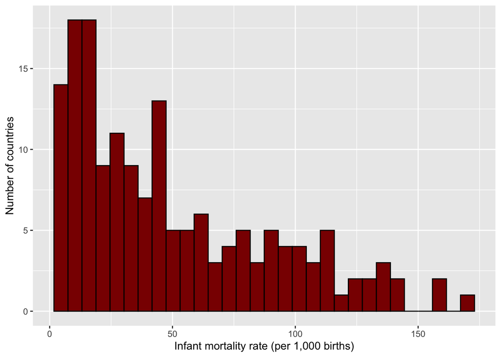

```r
table_df %>%
  ggplot(aes(infant_mortality)) +
  geom_histogram(color = "black", fill = "darkred") +
  xlab("Infant mortality rate (per 1,000 births)") +
  ylab("Number of countries")
```

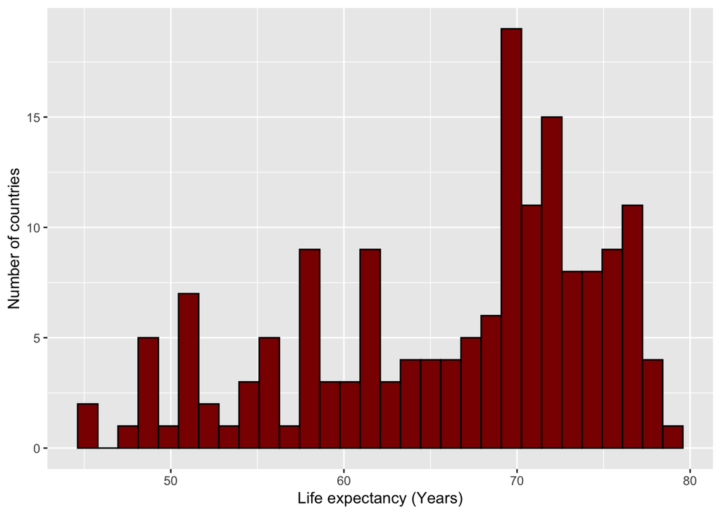

```r
table_df %>%
  ggplot(aes(life_expectancy)) +
  geom_histogram(color = "black", fill = "darkred") +
  xlab("Life expectancy (Years)") +
  ylab("Number of countries")
```

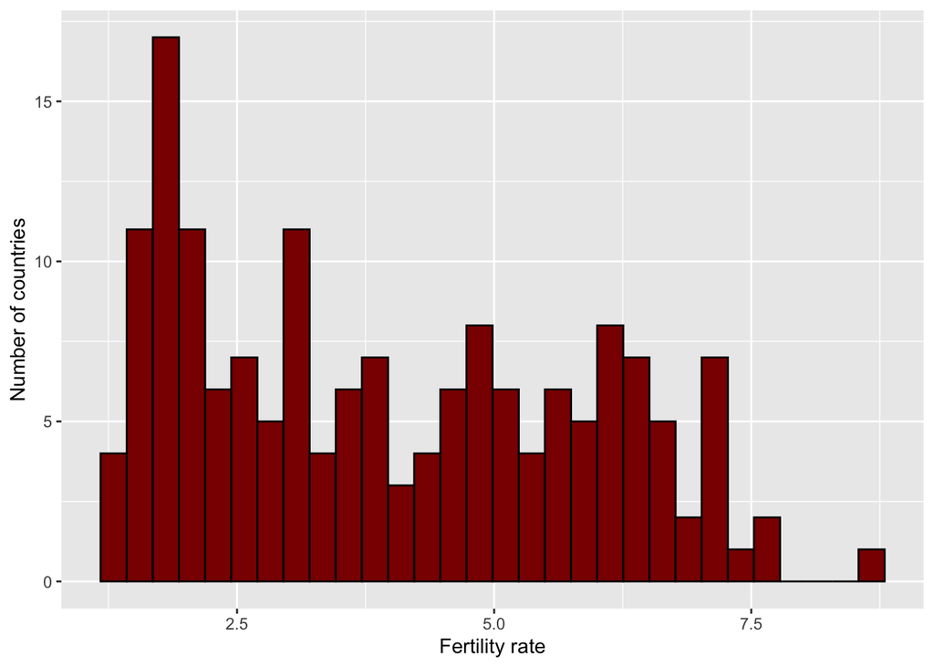

```r
table_df %>%
  ggplot(aes(fertility)) +
  geom_histogram(color = "black", fill = "darkred") +
  xlab("Fertility rate") +
  ylab("Number of countries")
```

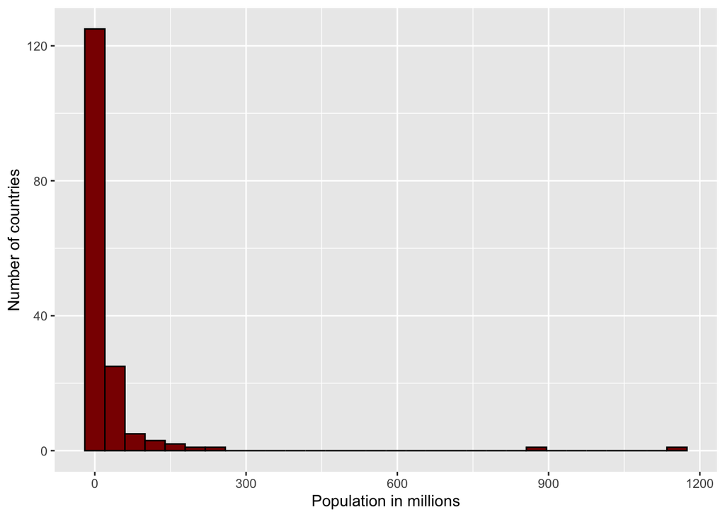

```r
table_df %>%
  ggplot(aes(population/10^6)) +                  # Scale to millions for a readable axis
  geom_histogram(color = "black", fill = "darkred") +
  xlab("Population in millions") +
  ylab("Number of countries")
```

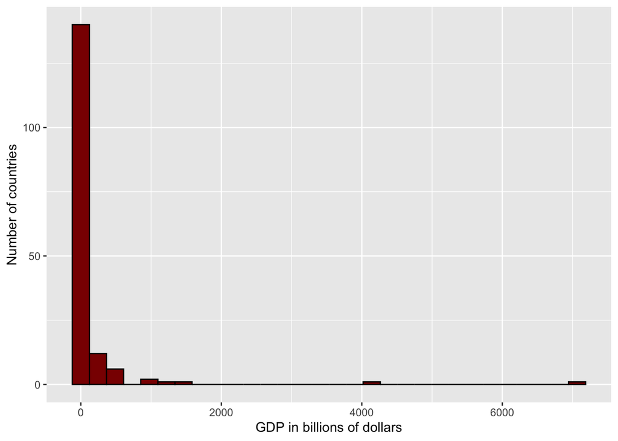

```r
table_df %>%
  ggplot(aes(gdp/10^9)) +                         # Scale to billions
  geom_histogram(color = "black", fill = "darkred") +
  xlab("GDP in billions of dollars") +
  ylab("Number of countries")
```

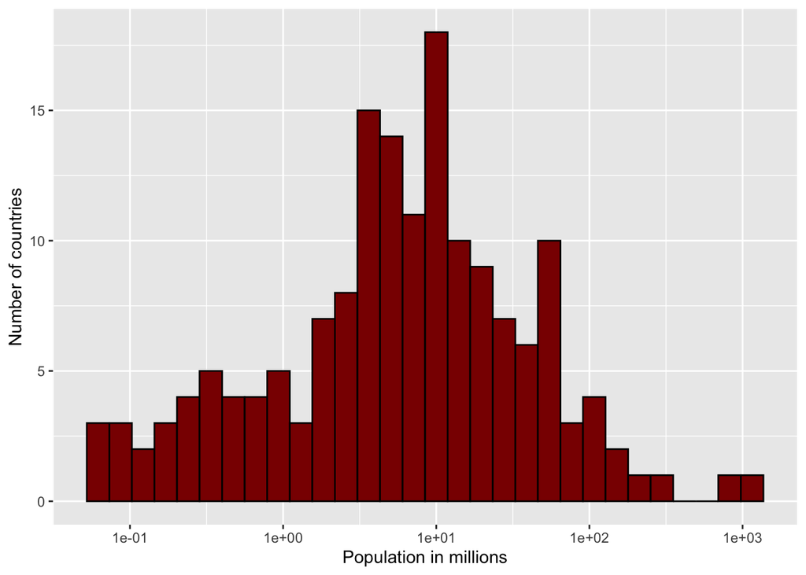

```r
# Population and GDP are very skewed; a log x-axis reveals the structure.
table_df %>%
  ggplot(aes(population/10^6)) +
  geom_histogram(color = "black", fill = "darkred") +
  xlab("Population in millions") +
  ylab("Number of countries") +
  scale_x_log10()                                 # NEW: log scale on x
```

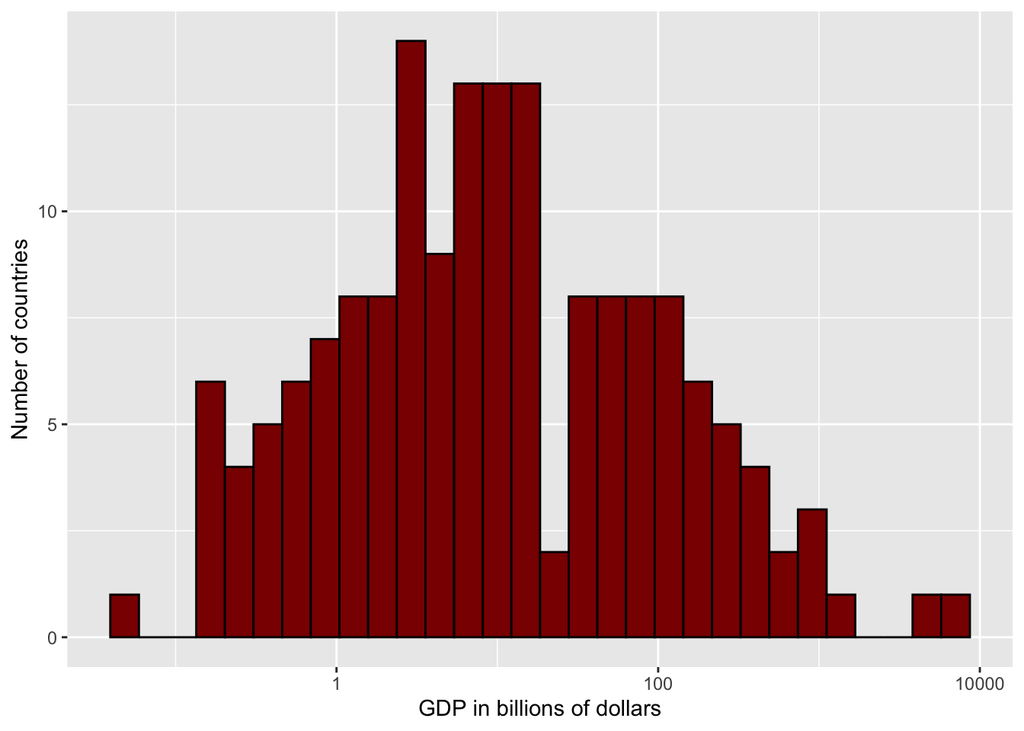

```r
table_df %>%
  ggplot(aes(gdp/10^9)) +
  geom_histogram(color = "black", fill = "darkred") +
  xlab("GDP in billions of dollars") +
  ylab("Number of countries") +
  scale_x_log10()
```

## 4.2 Printing medians and IQRs for non-normal variables

When variables are skewed (as above), report **median (IQR)** instead of mean (sd). In `tableone`, pass their names to the `nonnormal` argument of `kableone` (or `print`).

```r
nonNormalVars <- c("infant_mortality", "life_expectancy",
                   "fertility", "population", "gdp")

t1 <- CreateTableOne(vars = vars, data = table_df)
options(digits = 2)
kableone(t1, nonnormal = nonNormalVars)   # These print as median [IQR]
```

|  | Overall |
| --- | --- |
| n | 164 |
| infant_mortality (median [IQR]) | 38.40 [16.00, 77.15] |
| life_expectancy (median [IQR]) | 69.15 [60.40, 72.53] |
| fertility (median [IQR]) | 3.70 [2.16, 5.59] |
| population (median [IQR]) | 6765083.00 [2019378.75, 18343744.75] |
| gdp (median [IQR]) | 8224534133.00 [2170758367.50, 51772082085.75] |
| continent (%) |  |
| Africa | 49 (29.9) |
| Americas | 32 (19.5) |
| Asia | 38 (23.2) |
| Europe | 35 (21.3) |
| Oceania | 10 ( 6.1) |

## 4.3 Stratified Table 1

Stratification lets you compare groups side by side (here, continents). This is especially useful for highlighting regional differences — but be mindful of unequal group sizes.

```r
vars <- c("infant_mortality", "life_expectancy",
          "fertility", "population", "gdp")

nonNormalVars <- c("infant_mortality", "life_expectancy",
                   "fertility", "population", "gdp")

t1 <- CreateTableOne(vars = vars, data = table_df,
                     strata = "continent")        # One column per continent
options(digits = 2)
kableone(t1, nonnormal = nonNormalVars)
```

|  | Africa | Americas | Asia | Europe | Oceania | p | test |
| --- | --- | --- | --- | --- | --- | --- | --- |
| n | 49 | 32 | 38 | 35 | 10 |  |  |
| infant_mortality (median [IQR]) | 92.70 [63.00, 119.80] | 26.30 [19.45, 45.30] | 41.45 [21.35, 74.75] | 11.20 [7.35, 16.65] | 27.50 [20.22, 40.60] | <0.001 | nonnorm |
| life_expectancy (median [IQR]) | 56.10 [51.50, 61.30] | 71.50 [69.55, 73.35] | 68.70 [64.33, 71.72] | 74.20 [71.20, 76.75] | 64.70 [60.55, 69.10] | <0.001 | nonnorm |
| fertility (median [IQR]) | 6.21 [5.35, 6.65] | 3.09 [2.60, 3.83] | 3.80 [2.87, 5.08] | 1.81 [1.57, 2.00] | 4.72 [3.71, 4.95] | <0.001 | nonnorm |
| population (median [IQR]) | 7514201.00 [1597534.00, 13371971.00] | 4558551.50 [642280.50, 14821391.25] | 12206319.00 [3405013.50, 55625548.25] | 8821111.00 [4302244.50, 19202250.00] | 237357.00 [108906.50, 2730307.00] | 0.001 | nonnorm |
| gdp (median [IQR]) | 2590637104.00 [1019207023.00, 7062040511.00] | 7961843305.00 [2664939559.50, 37181495423.25] | 13348138779.00 [4889136750.50, 69268340898.75] | 71953291930.00 [14464231648.50, 193917649818.00] | 267752123.70 [184648934.78, 2101457579.25] | <0.001 | nonnorm |

Add an **Overall** column to contextualize the strata:

```r
vars <- c("infant_mortality", "life_expectancy",
          "fertility", "population", "gdp")

nonNormalVars <- c("infant_mortality", "life_expectancy",
                   "fertility", "population", "gdp")

t1 <- CreateTableOne(vars = vars, data = table_df,
                     strata = "continent", addOverall = TRUE)   # NEW: add an Overall column
options(digits = 2)
kableone(t1, nonnormal = nonNormalVars)
```

|  | Overall | Africa | Americas | Asia | Europe | Oceania | p | test |
| --- | --- | --- | --- | --- | --- | --- | --- | --- |
| n | 164 | 49 | 32 | 38 | 35 | 10 |  |  |
| infant_mortality (median [IQR]) | 38.40 [16.00, 77.15] | 92.70 [63.00, 119.80] | 26.30 [19.45, 45.30] | 41.45 [21.35, 74.75] | 11.20 [7.35, 16.65] | 27.50 [20.22, 40.60] | <0.001 | nonnorm |
| life_expectancy (median [IQR]) | 69.15 [60.40, 72.53] | 56.10 [51.50, 61.30] | 71.50 [69.55, 73.35] | 68.70 [64.33, 71.72] | 74.20 [71.20, 76.75] | 64.70 [60.55, 69.10] | <0.001 | nonnorm |
| fertility (median [IQR]) | 3.70 [2.16, 5.59] | 6.21 [5.35, 6.65] | 3.09 [2.60, 3.83] | 3.80 [2.87, 5.08] | 1.81 [1.57, 2.00] | 4.72 [3.71, 4.95] | <0.001 | nonnorm |
| population (median [IQR]) | 6765083.00 [2019378.75, 18343744.75] | 7514201.00 [1597534.00, 13371971.00] | 4558551.50 [642280.50, 14821391.25] | 12206319.00 [3405013.50, 55625548.25] | 8821111.00 [4302244.50, 19202250.00] | 237357.00 [108906.50, 2730307.00] | 0.001 | nonnorm |
| gdp (median [IQR]) | 8224534133.00 [2170758367.50, 51772082085.75] | 2590637104.00 [1019207023.00, 7062040511.00] | 7961843305.00 [2664939559.50, 37181495423.25] | 13348138779.00 [4889136750.50, 69268340898.75] | 71953291930.00 [14464231648.50, 193917649818.00] | 267752123.70 [184648934.78, 2101457579.25] | <0.001 | nonnorm |

## 4.4 Making tables publication-ready (labels and units)

Small presentation tweaks make a big difference:

- **Rename** variables to human-readable labels.
- **Rescale** units (e.g., millions or billions) so numbers are interpretable at a glance.
- **Limit** the number of decimal places printed.

```r
table_df <- gapminder %>%
  filter(year == 1990) %>%
  mutate(Population = population/10^6,     # Rescale to millions...
         GDP = gdp/10^9) %>%               # ...and billions
  rename("Infant mortality" = infant_mortality,   # Human-readable labels
         "Life expectancy" = life_expectancy,
         "Fertility" = fertility)

table_df <- table_df[complete.cases(table_df), ]

vars <- c("Infant mortality", "Life expectancy",
          "Fertility", "Population", "GDP")

nonNormalVars <- c("Infant mortality", "Life expectancy",
                   "Fertility", "Population", "GDP")

t1 <- CreateTableOne(vars = vars, data = table_df,
                     strata = "continent", addOverall = TRUE)
options(digits = 2)
kableone(t1, nonnormal = nonNormalVars)
```

|  | Overall | Africa | Americas | Asia | Europe | Oceania | p | test |
| --- | --- | --- | --- | --- | --- | --- | --- | --- |
| n | 164 | 49 | 32 | 38 | 35 | 10 |  |  |
| Infant mortality (median [IQR]) | 38.40 [16.00, 77.15] | 92.70 [63.00, 119.80] | 26.30 [19.45, 45.30] | 41.45 [21.35, 74.75] | 11.20 [7.35, 16.65] | 27.50 [20.22, 40.60] | <0.001 | nonnorm |
| Life expectancy (median [IQR]) | 69.15 [60.40, 72.53] | 56.10 [51.50, 61.30] | 71.50 [69.55, 73.35] | 68.70 [64.33, 71.72] | 74.20 [71.20, 76.75] | 64.70 [60.55, 69.10] | <0.001 | nonnorm |
| Fertility (median [IQR]) | 3.70 [2.16, 5.59] | 6.21 [5.35, 6.65] | 3.09 [2.60, 3.83] | 3.80 [2.87, 5.08] | 1.81 [1.57, 2.00] | 4.72 [3.71, 4.95] | <0.001 | nonnorm |
| Population (median [IQR]) | 6.77 [2.02, 18.34] | 7.51 [1.60, 13.37] | 4.56 [0.64, 14.82] | 12.21 [3.41, 55.63] | 8.82 [4.30, 19.20] | 0.24 [0.11, 2.73] | 0.001 | nonnorm |
| GDP (median [IQR]) | 8.22 [2.17, 51.77] | 2.59 [1.02, 7.06] | 7.96 [2.66, 37.18] | 13.35 [4.89, 69.27] | 71.95 [14.46, 193.92] | 0.27 [0.18, 2.10] | <0.001 | nonnorm |

# 5 Reporting Missing Data

Let’s start with the `gapminder` dataset again, and with a single year to avoid mixing temporal changes with cross-sectional patterns.

```r
library(tidyverse)
library(dslabs)
data(gapminder)

df <- gapminder %>%
  filter(year == 1965)   # One year only, for a clean cross-section

head(df)
```

|  | country | year | infant_mortality | life_expectancy | fertility | population | gdp | continent | region |
| --- | --- | --- | --- | --- | --- | --- | --- | --- | --- |
| 1 | Albania | 1965 | 94 | 67 | 5.6 | 1.9e+06 | NA | Europe | Southern Europe |
| 2 | Algeria | 1965 | 149 | 50 | 7.7 | 1.3e+07 | 1.4e+10 | Africa | Northern Africa |
| 3 | Angola | 1965 | NA | 39 | 7.4 | 5.8e+06 | NA | Africa | Middle Africa |
| 4 | Antigua and Barbuda | 1965 | NA | 65 | 4.2 | 6.0e+04 | NA | Americas | Caribbean |
| 5 | Argentina | 1965 | 59 | 66 | 3.1 | 2.2e+07 | 1.3e+11 | Americas | South America |
| 6 | Armenia | 1965 | NA | 69 | 4.0 | 2.2e+06 | NA | Asia | Western Asia |

A first high-level question: *How many cells are missing anywhere in the data frame?* We combine `sum` and `is.na` to count the missing values in the entire data frame.

```r
sum(is.na(df))   # is.na() returns TRUE/FALSE per cell; sum() counts the TRUEs
```

```
#> [1] 149
```

Next, check per-column missingness for key variables. This helps you see if the problem is concentrated (e.g., GDP) or widespread across multiple variables.

```r
# Per-variable counts (one call per column)
sum(is.na(df$country))
```

```
#> [1] 0
```

```r
sum(is.na(df$year))
```

```
#> [1] 0
```

```r
sum(is.na(df$infant_mortality))
```

```
#> [1] 66
```

```r
sum(is.na(df$life_expectancy))
```

```
#> [1] 0
```

```r
sum(is.na(df$fertility))
```

```
#> [1] 0
```

```r
sum(is.na(df$population))
```

```
#> [1] 0
```

```r
sum(is.na(df$gdp))
```

```
#> [1] 83
```

```r
sum(is.na(df$continent))
```

```
#> [1] 0
```

```r
sum(is.na(df$region))
```

```
#> [1] 0
```

Row- and column-wise utilities are handy for quick audits, or for filtering out rows with too much missingness.

```r
colSums(is.na(df))   # Missing count for every column at once
```

```
#>          country             year infant_mortality  life_expectancy
#>                0                0               66                0
#>        fertility       population              gdp        continent
#>                0                0               83                0
#>           region
#>                0
```

```r
rowSums(is.na(df))   # Missing count for every row
```

```
#>   [1] 1 0 2 2 0 2 2 0 0 2 1 1 0 0 2 0 1 0 2 0 2 0 0 2 1 0 0 2 0 0 2 0 1 0 0 0 2
#>  [38] 1 0 0 0 2 1 2 2 0 2 0 0 0 0 2 2 2 2 0 0 0 1 1 1 1 2 0 0 2 2 0 1 2 0 1 0 1
#>  [75] 0 0 0 0 0 1 1 1 0 1 0 1 2 0 1 0 1 2 2 1 1 0 0 1 2 0 2 2 0 0 0 1 1 1 0 1 0
#> [112] 2 2 2 2 0 1 2 0 0 1 1 0 1 0 0 0 0 0 0 0 0 0 1 0 1 2 2 2 0 2 1 2 2 0 2 0 0
#> [149] 0 2 2 1 1 0 0 0 2 1 0 1 0 2 1 0 2 0 1 0 0 0 2 1 2 1 0 0 0 2 1 0 2 1 1 0 0
```

For a richer one-pager that includes distributions and missingness summaries, the `skim` function from the `skimr` package is great:

```r
library(skimr)
skim(df)   # Per-variable summary: completeness, stats, and mini-histograms
```

Data summary

| Name | df |
| --- | --- |
| Number of rows | 185 |
| Number of columns | 9 |
| _______________________ |  |
| Column type frequency: |  |
| factor | 3 |
| numeric | 6 |
| ________________________ |  |
| Group variables | None |

**Variable type: factor**

| skim_variable | n_missing | complete_rate | ordered | n_unique | top_counts |
| --- | --- | --- | --- | --- | --- |
| country | 0 | 1 | FALSE | 185 | Alb: 1, Alg: 1, Ang: 1, Ant: 1 |
| continent | 0 | 1 | FALSE | 5 | Afr: 51, Asi: 47, Eur: 39, Ame: 36 |
| region | 0 | 1 | FALSE | 22 | Wes: 18, Eas: 16, Wes: 16, Car: 13 |

**Variable type: numeric**

| skim_variable | n_missing | complete_rate | mean | sd | p0 | p25 | p50 | p75 | p100 | hist |
| --- | --- | --- | --- | --- | --- | --- | --- | --- | --- | --- |
| year | 0 | 1.00 | 2.0e+03 | 0.0e+00 | 2.0e+03 | 2.0e+03 | 2.0e+03 | 2.0e+03 | 2.0e+03 | ▁▁▇▁▁ |
| infant_mortality | 66 | 0.64 | 9.7e+01 | 5.8e+01 | 1.4e+01 | 5.2e+01 | 9.6e+01 | 1.4e+02 | 2.6e+02 | ▇▅▆▂▁ |
| life_expectancy | 0 | 1.00 | 5.7e+01 | 1.1e+01 | 3.1e+01 | 4.8e+01 | 5.8e+01 | 6.7e+01 | 7.4e+01 | ▂▅▅▆▇ |
| fertility | 0 | 1.00 | 5.4e+00 | 1.8e+00 | 1.8e+00 | 3.6e+00 | 6.1e+00 | 6.8e+00 | 8.2e+00 | ▅▂▂▇▅ |
| population | 0 | 1.00 | 1.8e+07 | 6.7e+07 | 3.8e+04 | 7.5e+05 | 3.6e+06 | 9.5e+06 | 7.1e+08 | ▇▁▁▁▁ |
| gdp | 83 | 0.55 | 7.9e+10 | 3.4e+11 | 1.1e+08 | 1.4e+09 | 4.1e+09 | 2.7e+10 | 3.2e+12 | ▇▁▁▁▁ |

# 6 Visualizing Missingness

Visual displays make patterns and potential mechanisms (MCAR/MAR/NMAR) easier to spot. The `naniar` package contains functions that plot the missingness in data frames. We first rename variables for presentation (this does not change content, just the labels).

```r
library(naniar)

df <- df %>%
  rename("Infant mortality" = infant_mortality,
         "Life expectancy" = life_expectancy,
         "Population" = population,
         "Fertility" = fertility,
         "Continent" = continent,
         "Country" = country,
         "Region" = region,
         "Year" = year,
         "GDP" = gdp
         )
```

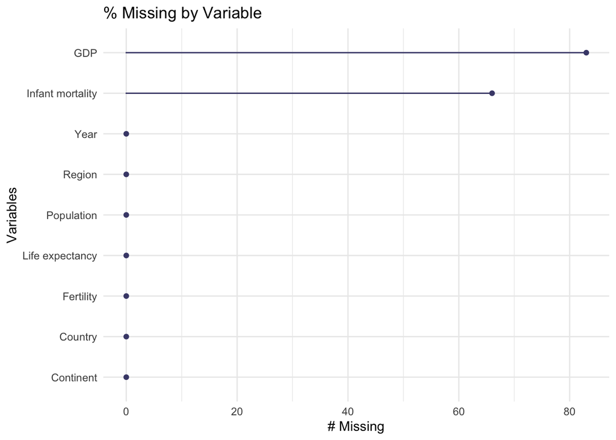

```r
gg_miss_var(df) +
  labs(title = "% Missing by Variable")
```

The `vis_miss` function plots a heatmap where each cell (rectangle) represents a value in the data frame. If the cell is black, that value is missing; if it’s gray, it’s present. The bottom of the plot also prints the percent missingness for the entire data frame. Here, we have 8.9% total missingness.

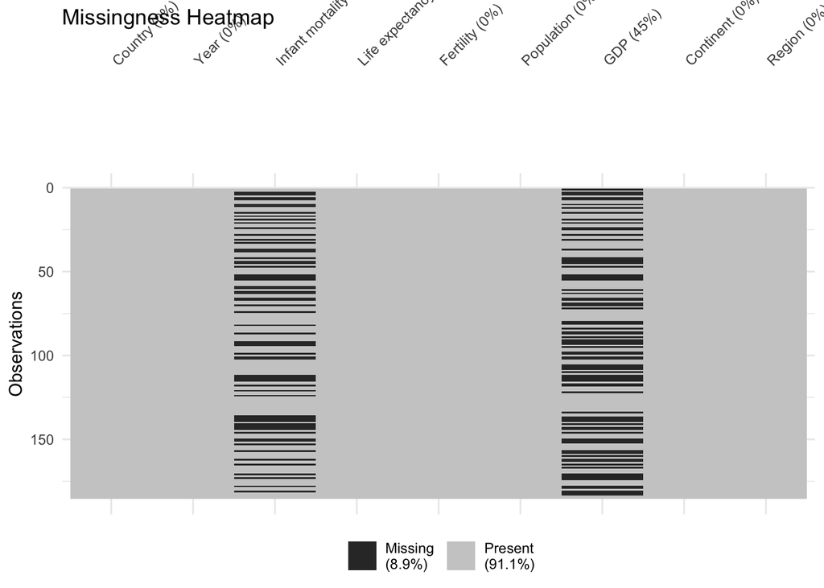

```r
vis_miss(df) +
  labs(title = "Missingness Heatmap")
```

Reading these plots

- **MCAR:** no structure in the plots.
- **MAR:** missingness associated with other observed variables (e.g., GDP missing more often in certain regions).
- **NMAR:** missingness depends on the unobserved value itself (harder to diagnose visually).

# 7 Self-Assessment Questions

Try each question **before** revealing the answer. They build from foundational to challenging and use the `gapminder` dataset. Click **“Show answer”** to check your work.

## 7.1 Beginner

**Q1.** Which base R function gives a quick min/median/mean/quartile summary of every column at once?

**Show answer**

`summary(df)`. For numeric columns it reports min, quartiles, median, and mean; for factors it gives category counts.

**Q2.** Write code to compute the mean and median of a numeric vector `x` that contains some `NA`s.

**Show answer**

```r
mean(x, na.rm = TRUE)
median(x, na.rm = TRUE)
```

`na.rm = TRUE` tells the function to ignore missing values.

**Q3.** For a right-skewed variable like GDP, should your Table 1 report mean (sd) or median (IQR)?

**Show answer**

**Median (IQR).** The median and IQR are robust to skew and outliers, so they describe a skewed distribution more faithfully than the mean and SD.

**Q4.** Write one line of code that counts the total number of missing cells in a data frame `df`.

**Show answer**

```r
sum(is.na(df))
```

`is.na(df)` returns a TRUE/FALSE for every cell; `sum()` counts the TRUEs.

**Q5.** Which function gives the number of missing values in **each column** at once?

**Show answer**

`colSums(is.na(df))`. (`rowSums(is.na(df))` does the same per row.)

## 7.2 Intermediate

**Q6.** Why does `summarize(r = range(x))` throw an error, and what are two ways to fix it?

**Show answer**

`range()` returns **two** values (min and max), but `summarize()` requires exactly one value per group. Fix it by using `min(x)` and `max(x)` as separate columns, or by switching to `reframe()`, which allows multi-value results.

**Q7.** You have a two-way `table()` of continent × fertility category. How do you get the proportions **within each continent** (so each continent’s row sums to 1)?

**Show answer**

```r
prop.table(tab, 1)   # margin = 1 -> row proportions
```

(`prop.table(tab, 2)` would give column proportions instead.)

**Q8.** What does `options(digits = 2)` do, and what does it *not* do?

**Show answer**

It controls how many significant digits are **displayed**. It does **not** round or change the underlying stored numbers — only their printed appearance.

## 7.3 Advanced

**Q9.** In `CreateTableOne`, what do the `strata` and `addOverall` arguments do?

**Show answer**

`strata` splits the table into one column per level of a grouping variable (e.g., a column per continent) so you can compare groups. `addOverall = TRUE` adds an extra column summarizing everyone together, for context alongside the strata.

**Q10.** Why remove rows with `complete.cases()` before building a Table 1, and what’s the risk?

**Show answer**

Many journals want a Table 1 with no missing values, and `complete.cases()` keeps only fully observed rows. The risk: if the data aren’t missing completely at random, dropping incomplete rows can **bias** the table toward whoever had complete data. Always check missingness first and report how much you dropped.

**Q11.** When would you use `reframe()` instead of `summarize()`, and why not just use it everywhere?

**Show answer**

Use `reframe()` when an expression legitimately returns **multiple values** per group (e.g., `range()`, `quantile()`, or a long-format stack of statistics). Don’t default to it everywhere: `summarize()` guarantees one row per group, which is what you want for most grouped summaries and is less error-prone.

# 8 Frequently Asked Questions (FAQ)

**Mean or median — how do I choose?** Use the **mean (with SD)** for roughly symmetric data, and the **median (with IQR)** for skewed data or data with outliers. A quick histogram tells you which you’re dealing with; in public health, income, GDP, and population are almost always skewed, so median/IQR is usually the honest choice.

**What’s the difference between `summarize()` and `reframe()`?** `summarize()` requires each statistic to return **one value per group** (one row per group out). `reframe()` allows expressions that return **several values**, so a group can produce several rows. Use `summarize()` by default; reach for `reframe()` only for multi-value results like `range()`.

**Why do I get an error when I put `range()` in `summarize()`?** Because `range()` returns two numbers and `summarize()` wants one. Replace it with `min()` and `max()` as two separate columns, or use `reframe()`.

**`prop.table(tab, 1)` vs `prop.table(tab, 2)` — which is which?** `1` = rows (each row sums to 1), `2` = columns (each column sums to 1). With no second argument, every cell is divided by the grand total. Multiply by 100 for percentages and wrap in `round()` to tidy the display.

**Does `options(digits = 2)` change my data?** No — it only changes how many digits R **prints**. Your underlying values keep full precision, so later calculations are unaffected. It’s purely cosmetic for cleaner tables.

**Should I always drop missing values before a Table 1?** Journals often expect a complete-case Table 1, but dropping rows can bias the summary if data aren’t missing completely at random. Check and report your missingness first (see the missingness lesson), and consider footnoting how many observations were excluded.

**How does `tableone` know to print median (IQR) instead of mean (sd)?** You tell it: pass the skewed variables’ names to the `nonnormal` argument of `kableone()` (or `print()`). Those variables then display as median [IQR]; the rest stay as mean (sd).

**How do I make the numbers in my table readable?** Rescale large quantities (population to millions, GDP to billions) with a `mutate()`, give variables human-readable names with `rename()`, and limit printed digits with `options(digits = 2)`. Small touches, big difference in a published table.

The big picture Good summaries match the data: means and SDs for symmetric variables, medians and IQRs for skewed ones, and frequency tables for categories. The `tableone` package turns these into a clean, journal-ready Table 1 — but the statistics are only as honest as your handling of skew and missingness, so check both before you publish.